# Bayesian modelling part4

Author

Fimareti Selu

Published

19/10/2023

# 1 Preparations

Load the necessary libraries

```r
library(tidyverse)
library(easystats)
library(knitr)
library(sf)
library(rnaturalearth)
library(maps)
library(brms)
library(rstan)
library(tidybayes)
library(patchwork)
library(DHARMa)
library(HDInterval)
library(emmeans)
source('helperFunctions.R')
```

# 2 Read in the data

```r
dat <- read_csv("../data/Samoa_Waitt_updated.csv", trim_ws = TRUE)
```

```r
labelset <- read_csv("../data/ReefCloudlabelset.csv", trim_ws = TRUE)
```

**glimpse**

```r
dat |> glimpse()
```

```
Rows: 7,115
Columns: 47
$ project_id                    <dbl> 767, 767, 767, 767, 767, 767, 767, 767, …
$ project_name                  <chr> "SAMOA_Waitt", "SAMOA_Waitt", "SAMOA_Wai…
$ project_description           <chr> "Waitt Foundation and SCRIPPS Expedition…
$ project_field_of_view         <chr> "50-100cm", "50-100cm", "50-100cm", "50-…
$ project_method                <chr> "[\"Dive\"]", "[\"Dive\"]", "[\"Dive\"]"…
$ project_countries             <chr> "[\"Samoa\"]", "[\"Samoa\"]", "[\"Samoa\…
$ project_protocol              <chr> "[\"Photo transects\"]", "[\"Photo trans…
$ project_global_region         <chr> "[\"Pacific\"]", "[\"Pacific\"]", "[\"Pa…
$ project_organisations         <chr> "[\"Ministry of Natural Resources & Envi…
$ site_id                       <dbl> 18547, 18547, 18547, 18547, 18547, 18547…
$ site_name                     <chr> "SAV_13", "SAV_13", "SAV_13", "SAV_13", …
$ site_latitude                 <dbl> -13.48, -13.48, -13.48, -13.48, -13.48, …
$ site_longitude                <dbl> -172.57, -172.57, -172.57, -172.57, -172…
```

[output cut: 34 more lines]

**head**

```r
## Explore the first 6 rows of the data
dat |> head()
```

```
# A tibble: 6 × 47
  project_id project_name project_description              project_field_of_view
       <dbl> <chr>        <chr>                            <chr>
1        767 SAMOA_Waitt  Waitt Foundation and SCRIPPS Ex… 50-100cm
2        767 SAMOA_Waitt  Waitt Foundation and SCRIPPS Ex… 50-100cm
3        767 SAMOA_Waitt  Waitt Foundation and SCRIPPS Ex… 50-100cm
4        767 SAMOA_Waitt  Waitt Foundation and SCRIPPS Ex… 50-100cm
5        767 SAMOA_Waitt  Waitt Foundation and SCRIPPS Ex… 50-100cm
6        767 SAMOA_Waitt  Waitt Foundation and SCRIPPS Ex… 50-100cm
# ℹ 43 more variables: project_method <chr>, project_countries <chr>,
#   project_protocol <chr>, project_global_region <chr>,
#   project_organisations <chr>, site_id <dbl>, site_name <chr>,
#   site_latitude <dbl>, site_longitude <dbl>, site_depth <dbl>,
#   site_country <chr>, site_reef_name <lgl>, site_exposure <lgl>,
#   site_reef_type <chr>, site_reef_zone <chr>, site_code <chr>,
#   site_management <lgl>, site_local_region <lgl>, …
```

**str**

```r
dat |> str()
```

```
spc_tbl_ [7,115 × 47] (S3: spec_tbl_df/tbl_df/tbl/data.frame)
 $ project_id                   : num [1:7115] 767 767 767 767 767 767 767 767 767 767 ...
 $ project_name                 : chr [1:7115] "SAMOA_Waitt" "SAMOA_Waitt" "SAMOA_Waitt" "SAMOA_Waitt" ...
 $ project_description          : chr [1:7115] "Waitt Foundation and SCRIPPS Expedition in colleboration with MNRE to survey reefs around Upolu and Sava'i. Thi"| __truncated__ "Waitt Foundation and SCRIPPS Expedition in colleboration with MNRE to survey reefs around Upolu and Sava'i. Thi"| __truncat…
 $ project_field_of_view        : chr [1:7115] "50-100cm" "50-100cm" "50-100cm" "50-100cm" ...
 $ project_method               : chr [1:7115] "[\"Dive\"]" "[\"Dive\"]" "[\"Dive\"]" "[\"Dive\"]" ...
 $ project_countries            : chr [1:7115] "[\"Samoa\"]" "[\"Samoa\"]" "[\"Samoa\"]" "[\"Samoa\"]" ...
 $ project_protocol             : chr [1:7115] "[\"Photo transects\"]" "[\"Photo transects\"]" "[\"Photo transects\"]" "[\"Photo transects\"]" ...
 $ project_global_region        : chr [1:7115] "[\"Pacific\"]" "[\"Pacific\"]" "[\"Pacific\"]" "[\"Pacific\"]" ...
 $ project_organisations        : chr [1:7115] "[\"Ministry of Natural Resources & Environment - Samoa\", \"Waitt Foundation\"]" "[\"Ministry of Natural Resources & Environment - Samoa\", \"Waitt Foundation\"]" "[\"Ministry of Natural Resources & Environment - Samoa\", \"Waitt Foundation\"]" "[\"Min…
 $ site_id                      : num [1:7115] 18547 18547 18547 18547 18547 ...
 $ site_name                    : chr [1:7115] "SAV_13" "SAV_13" "SAV_13" "SAV_13" ...
 $ site_latitude                : num [1:7115] -13.5 -13.5 -13.5 -13.5 -13.5 ...
 $ site_longitude               : num [1:7115] -173 -173 -173 -173 -173 ...
 $ site_depth                   : num [1:7115] 10 10 10 10 10 10 10 10 10 10 ...
 $ site_country                 : chr [1:7115] "Samoa" "Samoa" "Samoa" "Samoa" ...
 $ site_reef_name               : logi [1:7115] NA NA NA NA NA NA ...
 $ site_exposure                : logi [1:7115] NA NA NA NA NA NA ...
 $ site_reef_type               : chr [1:7115] "fringing" "fringing" "fringing" "fringing" ...
 $ site_reef_zone               : chr [1:7115] "fore reef" "fore reef" "fore reef" "fore reef" ...
 $ site_code                    : chr [1:7115] "SAV_13" "SAV_13" "SAV_13" "SAV_13" ...
 $ site_management              : logi [1:7115] NA NA NA NA NA NA ...
 $ site_local_region            : logi [1:7115] NA NA NA NA NA NA ...
 $ site_country_region          : chr [1:7115] "Savaii" "Savaii" "Savaii" "Savaii" ...
 $ survey_id                    : num [1:7115] 44110 44110 44110 44110 44110 ...
 $ survey_title                 : chr [1:7115] "SAV_13_20220914_T1" "SAV_13_20220914_T1" "SAV_13_20220914_T1" "SAV_13_20220914_T1" ...
 $ survey_description           : logi [1:7115] NA NA NA NA NA NA ...
 $ survey_start_date            : POSIXct[1:7115], format: "2022-09-14 07:30:00" "2022-09-14 07:30:00" ...
 $ survey_collection_method     : chr [1:7115] "Dive" "Dive" "Dive" "Dive" ...
 $ survey_depth                 : num [1:7115] 10 10 10 10 10 10 10 10 10 10 ...
 $ survey_transect_number       : num [1:7115] 1 1 1 1 1 1 1 1 1 1 ...
 $ image_id                     : num [1:7115] 3283603 3283603 3283603 3283603 3283603 ...
 $ image_name                   : chr [1:7115] "SAV_13_20220914_T1_01.JPG" "SAV_13_20220914_T1_01.JPG" "SAV_13_20220914_T1_01.JPG" "SAV_13_20220914_T1_01.JPG" ...
 $ image_path                   : chr [1:7115] "surveys/SAMOA_Waitt/44110/2e4da4f9-9b8a-44f9-9a7d-f164e93c9779/SAV_13_20220914_T1_01.JPG" "surveys/SAMOA_Waitt/44110/2e4da4f9-9b8a-44f9-9a7d-f164e93c9779/SAV_13_20220914_T1_01.JPG" "surveys/SAMOA_Waitt/44110/2e4da4f9-9b8a-44f9-9a7d-f164e93c9779/SAV_13_…
 $ image_height                 : num [1:7115] 3000 3000 3000 3000 3000 3000 3000 3000 3000 3000 ...
 $ image_width                  : num [1:7115] 4000 4000 4000 4000 4000 4000 4000 4000 4000 4000 ...
 $ image_quality                : logi [1:7115] NA NA NA NA NA NA ...
 $ image_disabled               : logi [1:7115] FALSE FALSE FALSE FALSE FALSE FALSE ...
 $ point_id                     : num [1:7115] 1.34e+08 1.34e+08 1.34e+08 1.34e+08 1.34e+08 ...
 $ point_num                    : num [1:7115] 1 2 3 4 5 1 2 3 4 5 ...
```

[output cut: 44 more lines]

```
  ..   image_width = col_double(),
  ..   image_quality = col_logical(),
  ..   image_disabled = col_logical(),
  ..   point_id = col_double(),
  ..   point_num = col_double(),
  ..   point_machine_classification = col_character(),
  ..   point_human_classification = col_character(),
  ..   point_human_group_code = col_character(),
  ..   point_coordinate = col_character(),
  ..   point_model_confidence = col_logical(),
  ..   point_modified_by_displayname = col_character(),
  ..   point_modified_by_username = col_character(),
  ..   point_modified_by_email = col_character()
  .. )
 - attr(*, "problems")=<externalptr>
```

**Easystats (datawizard)**

```r
dat |> datawizard::data_codebook() |> knitr::kable()
```

| ID | Name | Type | Missings | Values | N | Prop | .row_id |
| --- | --- | --- | --- | --- | --- | --- | --- |
| 1 | project_id | numeric | 0 (0.0%) | 767 | 7115 | 100.0% | 1 |
|  |  |  |  |  |  |  | 1 |
| 2 | project_name | character | 0 (0.0%) | SAMOA_Waitt | 7115 | 100.0% | 2 |
|  |  |  |  |  |  |  | 2 |
| 3 | project_description | character | 0 (0.0%) | Waitt Foundation and SCRIPPS Expedition in colleboration with MNRE to survey reefs around Upolu and Sava’i. This includes Phototransects, fish, invertebrates and macroalgae surveys. Also the 100 Islan… | 7115 | 100.0% | 3 |
|  |  |  |  |  |  |  | 3 |
| 4 | project_field_of_view | character | 0 (0.0%) | 50-100cm | 7115 | 100.0% | 4 |
|  |  |  |  |  |  |  | 4 |
| 5 | project_method | character | 0 (0.0%) | [“Dive”] | 7115 | 100.0% | 5 |
|  |  |  |  |  |  |  | 5 |
| 6 | project_countries | character | 0 (0.0%) | [“Samoa”] | 7115 | 100.0% | 6 |
|  |  |  |  |  |  |  | 6 |
| 7 | project_protocol | character | 0 (0.0%) | [“Photo transects”] | 7115 | 100.0% | 7 |
|  |  |  |  |  |  |  | 7 |
| 8 | project_global_region | character | 0 (0.0%) | [“Pacific”] | 7115 | 100.0% | 8 |
|  |  |  |  |  |  |  | 8 |
| 9 | project_organisations | character | 0 (0.0%) | [“Ministry of Natural Resources & Environment - Samoa”, “Waitt Foundation”] | 7115 | 100.0% | 9 |
|  |  |  |  |  |  |  | 9 |
| 10 | site_id | numeric | 0 (0.0%) | [18542, 18577] | 7115 |  | 10 |
|  |  |  |  |  |  |  | 10 |
| 11 | site_name | character | 0 (0.0%) | SAV_13 | 220 | 3.1% | 11 |
|  |  |  |  | SAV_15 | 210 | 3.0% | 11 |
|  |  |  |  | SAV_18 | 220 | 3.1% | 11 |
|  |  |  |  | SAV_19 | 210 | 3.0% | 11 |
|  |  |  |  | SAV_21 | 210 | 3.0% | 11 |
|  |  |  |  | SAV_23 | 210 | 3.0% | 11 |
|  |  |  |  | SAV_25 | 230 | 3.2% | 11 |
|  |  |  |  | SAV_26 | 210 | 3.0% | 11 |
|  |  |  |  | SAV_27 | 200 | 2.8% | 11 |
|  |  |  |  | SAV_30 | 215 | 3.0% | 11 |

[output cut: 182 more lines]

# 3 Data preparation

Before we can model these data, they need to be processed into a format compatible with statistical modelling. The necessary wrangling steps:

1. exclude extraneous (unneeded) fields
2. exclude poor images
3. lengthen the data with respect to classification type
4. join to a labelset lookup
5. tally up the points per date/image/GROUP/type
6. recode transect id
7. fill in the gaps and add the zeros
8. sum to transect level
9. generate a Year field from the sample date

**Exclude fields**

Although it is often harmless enough to retain the other fields, it does make reviewing the data more combersum, so at an early stage within this exercise, we will probably restrict the data to just the above fields.

```r
dat <- dat |>
  dplyr::select(site_id,
    site_name,
    site_latitude,
    site_longitude,
    survey_start_date,
    survey_depth,
    survey_transect_number,
    image_id,
    image_quality,
    point_id,
    point_num,
    point_machine_classification,
    point_human_classification
    )
dat |> as.data.frame() |> head()
```

```
  site_id site_name site_latitude site_longitude   survey_start_date
1   18547    SAV_13        -13.48        -172.57 2022-09-14 07:30:00
2   18547    SAV_13        -13.48        -172.57 2022-09-14 07:30:00
3   18547    SAV_13        -13.48        -172.57 2022-09-14 07:30:00
4   18547    SAV_13        -13.48        -172.57 2022-09-14 07:30:00
5   18547    SAV_13        -13.48        -172.57 2022-09-14 07:30:00
6   18547    SAV_13        -13.48        -172.57 2022-09-14 07:30:00
  survey_depth survey_transect_number image_id image_quality  point_id
1           10                      1  3283603            NA 133694247
2           10                      1  3283603            NA 133694248
3           10                      1  3283603            NA 133694249
4           10                      1  3283603            NA 133694250
5           10                      1  3283603            NA 133694251
6           10                      1  3283602            NA 133694197
  point_num point_machine_classification point_human_classification
1         1                           TA                       <NA>
2         2                           TA                       <NA>
3         3                           TA                       <NA>
4         4                       MA_ENC                       <NA>
5         5                           MA                       <NA>
6         1                           UN                       <NA>
```

**Excluding poor images**

```r
dat <-
  dat |>
  dplyr::filter(is.na(image_quality) | image_quality != 0)
dat |> as.data.frame() |> head()
```

```
  site_id site_name site_latitude site_longitude   survey_start_date
1   18547    SAV_13        -13.48        -172.57 2022-09-14 07:30:00
2   18547    SAV_13        -13.48        -172.57 2022-09-14 07:30:00
3   18547    SAV_13        -13.48        -172.57 2022-09-14 07:30:00
4   18547    SAV_13        -13.48        -172.57 2022-09-14 07:30:00
5   18547    SAV_13        -13.48        -172.57 2022-09-14 07:30:00
6   18547    SAV_13        -13.48        -172.57 2022-09-14 07:30:00
  survey_depth survey_transect_number image_id image_quality  point_id
1           10                      1  3283603            NA 133694247
2           10                      1  3283603            NA 133694248
3           10                      1  3283603            NA 133694249
4           10                      1  3283603            NA 133694250
5           10                      1  3283603            NA 133694251
6           10                      1  3283602            NA 133694197
  point_num point_machine_classification point_human_classification
1         1                           TA                       <NA>
2         2                           TA                       <NA>
3         3                           TA                       <NA>
4         4                       MA_ENC                       <NA>
5         5                           MA                       <NA>
6         1                           UN                       <NA>
```

```r
dat |> dim()
```

```
[1] 7115   13
```

**Lengthen the data**

```r
dat <-
  dat |>
  pivot_longer(cols = matches("point_.*_classification"),
    names_to = "type",
    values_to = "classification"
    )
dat |> as.data.frame() |> head()
```

```
  site_id site_name site_latitude site_longitude   survey_start_date
1   18547    SAV_13        -13.48        -172.57 2022-09-14 07:30:00
2   18547    SAV_13        -13.48        -172.57 2022-09-14 07:30:00
3   18547    SAV_13        -13.48        -172.57 2022-09-14 07:30:00
4   18547    SAV_13        -13.48        -172.57 2022-09-14 07:30:00
5   18547    SAV_13        -13.48        -172.57 2022-09-14 07:30:00
6   18547    SAV_13        -13.48        -172.57 2022-09-14 07:30:00
  survey_depth survey_transect_number image_id image_quality  point_id
1           10                      1  3283603            NA 133694247
2           10                      1  3283603            NA 133694247
3           10                      1  3283603            NA 133694248
4           10                      1  3283603            NA 133694248
5           10                      1  3283603            NA 133694249
6           10                      1  3283603            NA 133694249
  point_num                         type classification
1         1 point_machine_classification             TA
2         1   point_human_classification           <NA>
3         2 point_machine_classification             TA
4         2   point_human_classification           <NA>
5         3 point_machine_classification             TA
6         3   point_human_classification           <NA>
```

**Joining to the group code lookup data**

Our primary interest in these data will be in exploring patterns in broad taxanomic groups such as *Hard coral* and *algae*. Since the machine learning tools behind ReefCloud are tuned to classify to finer taxonomic resolutions, next task will be to use a lookup table so as to assign the higher order group codes (HC and A) to the data.

**glimpse**

```r
labelset |> glimpse()
```

```
Rows: 220
Columns: 4
$ CODE                     <chr> "CA", "BM", "BM_MM", "EA", "HA", "HC", "HC_AC…
$ DESCRIPTION              <chr> "Crustose Coralline Algae", "Cyanobacterial M…
$ `FUNCTIONAL GROUP`       <chr> "CA", "BM", "BM", "EA", "HA", "HC", "HC", "HC…
$ `KEYBOARD SHORTCUT CODE` <lgl> NA, NA, NA, NA, NA, NA, NA, NA, NA, NA, NA, N…
```

**head**

```r
## Explore the first 6 rows of the labelseta
labelset |> head()
```

```
# A tibble: 6 × 4
  CODE  DESCRIPTION                    `FUNCTIONAL GROUP` KEYBOARD SHORTCUT CO…¹
  <chr> <chr>                          <chr>              <lgl>
1 CA    Crustose Coralline Algae       CA                 NA
2 BM    Cyanobacterial Mats            BM                 NA
3 BM_MM Cyanobacterial Mats - Other M… BM                 NA
4 EA    Erect Coralline Algae          EA                 NA
5 HA    Halimeda                       HA                 NA
6 HC    Hard Coral                     HC                 NA
# ℹ abbreviated name: ¹`KEYBOARD SHORTCUT CODE`
```

**str**

```r
labelset |> str()
```

```
spc_tbl_ [220 × 4] (S3: spec_tbl_df/tbl_df/tbl/data.frame)
 $ CODE                  : chr [1:220] "CA" "BM" "BM_MM" "EA" ...
 $ DESCRIPTION           : chr [1:220] "Crustose Coralline Algae" "Cyanobacterial Mats" "Cyanobacterial Mats - Other Microbial Mats" "Erect Coralline Algae" ...
 $ FUNCTIONAL GROUP      : chr [1:220] "CA" "BM" "BM" "EA" ...
 $ KEYBOARD SHORTCUT CODE: logi [1:220] NA NA NA NA NA NA ...
 - attr(*, "spec")=
  .. cols(
  ..   CODE = col_character(),
  ..   DESCRIPTION = col_character(),
  ..   `FUNCTIONAL GROUP` = col_character(),
  ..   `KEYBOARD SHORTCUT CODE` = col_logical()
  .. )
 - attr(*, "problems")=<externalptr>
```

**Easystats (datawizard)**

```r
labelset |> datawizard::data_codebook() |> knitr::kable()
```

| ID | Name | Type | Missings | Values | N | Prop | .row_id |
| --- | --- | --- | --- | --- | --- | --- | --- |
| 1 | CODE | character | 0 (0.0%) | BI | 1 | 0.5% | 1 |
|  |  |  |  | BI_ACT | 1 | 0.5% | 1 |
|  |  |  |  | BI_ASC | 1 | 0.5% | 1 |
|  |  |  |  | BI_COR | 1 | 0.5% | 1 |
|  |  |  |  | BI_HEL | 1 | 0.5% | 1 |
|  |  |  |  | BI_HYR | 1 | 0.5% | 1 |
|  |  |  |  | BI_MIL | 1 | 0.5% | 1 |
|  |  |  |  | BI_ZOA | 1 | 0.5% | 1 |
|  |  |  |  | BM | 1 | 0.5% | 1 |
|  |  |  |  | BM_MM | 1 | 0.5% | 1 |
|  |  |  |  | (…) | NA | NA | 1 |
|  |  |  |  |  |  |  | 1 |
| 2 | DESCRIPTION | character | 0 (0.0%) | Crustose Coralline Algae | 1 | 0.5% | 2 |
|  |  |  |  | Cyanobacterial Mats | 1 | 0.5% | 2 |
|  |  |  |  | Cyanobacterial Mats - Other Microbial Mats | 1 | 0.5% | 2 |
|  |  |  |  | Erect Coralline Algae | 1 | 0.5% | 2 |
|  |  |  |  | Halimeda | 1 | 0.5% | 2 |
|  |  |  |  | Hard Coral | 1 | 0.5% | 2 |
|  |  |  |  | Hard Coral - Acroporidae | 1 | 0.5% | 2 |
|  |  |  |  | Hard Coral - Acroporidae - Acropora | 1 | 0.5% | 2 |
|  |  |  |  | Hard Coral - Acroporidae - Alveopora | 1 | 0.5% | 2 |
|  |  |  |  | Hard Coral - Acroporidae - Anacropora | 1 | 0.5% | 2 |
|  |  |  |  | (…) | NA | NA | 2 |
|  |  |  |  |  |  |  | 2 |
| 3 | FUNCTIONAL GROUP | character | 0 (0.0%) | BI | 8 | 3.6% | 3 |
|  |  |  |  | BM | 2 | 0.9% | 3 |
|  |  |  |  | CA | 1 | 0.5% | 3 |
|  |  |  |  | EA | 1 | 0.5% | 3 |
|  |  |  |  | HA | 1 | 0.5% | 3 |
|  |  |  |  | HC | 35 | 15.9% | 3 |
|  |  |  |  | HC_ACO | 3 | 1.4% | 3 |
|  |  |  |  | HC_ACR | 7 | 3.2% | 3 |
|  |  |  |  | HC_AGA | 5 | 2.3% | 3 |
|  |  |  |  | HC_ASG | 1 | 0.5% | 3 |
|  |  |  |  | (…) | NA | NA | 3 |
|  |  |  |  |  |  |  | 3 |

```r
dat <-
  dat |>
  left_join(labelset |>
              dplyr::select(CODE, GROUP = `FUNCTIONAL GROUP`),
              by = c("classification" = "CODE")
    ) |>
  mutate(GROUP = ifelse(str_detect(GROUP, "HC_.*"), "HC", GROUP))
dat |> as.data.frame() |> head()
```

```
  site_id site_name site_latitude site_longitude   survey_start_date
1   18547    SAV_13        -13.48        -172.57 2022-09-14 07:30:00
2   18547    SAV_13        -13.48        -172.57 2022-09-14 07:30:00
3   18547    SAV_13        -13.48        -172.57 2022-09-14 07:30:00
4   18547    SAV_13        -13.48        -172.57 2022-09-14 07:30:00
5   18547    SAV_13        -13.48        -172.57 2022-09-14 07:30:00
6   18547    SAV_13        -13.48        -172.57 2022-09-14 07:30:00
  survey_depth survey_transect_number image_id image_quality  point_id
1           10                      1  3283603            NA 133694247
2           10                      1  3283603            NA 133694247
3           10                      1  3283603            NA 133694248
4           10                      1  3283603            NA 133694248
5           10                      1  3283603            NA 133694249
6           10                      1  3283603            NA 133694249
  point_num                         type classification GROUP
1         1 point_machine_classification             TA    TA
2         1   point_human_classification           <NA>  <NA>
3         2 point_machine_classification             TA    TA
4         2   point_human_classification           <NA>  <NA>
5         3 point_machine_classification             TA    TA
6         3   point_human_classification           <NA>  <NA>
```

**Exclude rows without classification**

```r
dat <- dat |>
  filter(!is.na(classification)) |>
  droplevels()
```

**Tally up points**

Count the number of points of each type as well as sum up the total number of points per image.

```r
dat <-
  dat |>
  group_by(across(c(starts_with("site"),
    starts_with("survey"),
    type,
    image_id,
    GROUP))
  ) |>
  summarise(COUNT = n(), .groups = "keep") |>
  ungroup(GROUP) |>
  mutate(TOTAL = sum(COUNT)) |>
  ungroup()
dat |> as.data.frame() |> head()
```

```
  site_id site_name site_latitude site_longitude   survey_start_date
1   18542    SAV_27        -13.57        -172.75 2022-09-12 10:01:00
2   18542    SAV_27        -13.57        -172.75 2022-09-12 10:01:00
3   18542    SAV_27        -13.57        -172.75 2022-09-12 10:01:00
4   18542    SAV_27        -13.57        -172.75 2022-09-12 10:01:00
5   18542    SAV_27        -13.57        -172.75 2022-09-12 10:01:00
6   18542    SAV_27        -13.57        -172.75 2022-09-12 10:01:00
  survey_depth survey_transect_number                         type image_id
1           10                      1 point_machine_classification  3284036
2           10                      1 point_machine_classification  3284036
3           10                      1 point_machine_classification  3284036
4           10                      1 point_machine_classification  3284037
5           10                      1 point_machine_classification  3284037
6           10                      1 point_machine_classification  3284038
  GROUP COUNT TOTAL
1    CA     3     5
2    HS     1     5
3    TA     1     5
4    CA     4     5
5    HC     1     5
6    CA     4     5
```

**Recode transects**

```r
dat <-
  dat |>
  mutate(transect_id = paste0(site_id, survey_transect_number))
dat |> as.data.frame() |> head()
```

```
  site_id site_name site_latitude site_longitude   survey_start_date
1   18542    SAV_27        -13.57        -172.75 2022-09-12 10:01:00
2   18542    SAV_27        -13.57        -172.75 2022-09-12 10:01:00
3   18542    SAV_27        -13.57        -172.75 2022-09-12 10:01:00
4   18542    SAV_27        -13.57        -172.75 2022-09-12 10:01:00
5   18542    SAV_27        -13.57        -172.75 2022-09-12 10:01:00
6   18542    SAV_27        -13.57        -172.75 2022-09-12 10:01:00
  survey_depth survey_transect_number                         type image_id
1           10                      1 point_machine_classification  3284036
2           10                      1 point_machine_classification  3284036
3           10                      1 point_machine_classification  3284036
4           10                      1 point_machine_classification  3284037
5           10                      1 point_machine_classification  3284037
6           10                      1 point_machine_classification  3284038
  GROUP COUNT TOTAL transect_id
1    CA     3     5      185421
2    HS     1     5      185421
3    TA     1     5      185421
4    CA     4     5      185421
5    HC     1     5      185421
6    CA     4     5      185421
```

**Fill in any gaps**

Since the data represent the classification of points in images, they only include what was present, not what was also absent. For example, if all five points are Algae, then this also means that all other functional groups are absent - yet this information is lacking in the data. For modelling purposes it is vital that we fill in all the zero values.

To do so, we must create a data set that contains every GROUP in every IMAGE.

```r
GROUPS <- dat |> pull(GROUP) |> unique()
data.filler <- dat %>%
  dplyr::select(
    starts_with("site"),
    survey_start_date,
    #Year,
    survey_depth,
    transect_id,
    image_id,
    type,
    ## GROUP,
    TOTAL) |>
  distinct() |>
 tidyr::crossing(GROUP = GROUPS)

dat <-
  dat |>
  full_join(data.filler) |>
  group_by(
    across(c(starts_with("site"),
      survey_start_date,
      #Year,
      survey_depth,
      transect_id,
      image_id,
      type,
      GROUP
    ))) |>
  mutate(COUNT = ifelse(is.na(COUNT), 0, COUNT),
    TOTAL = max(TOTAL, na.rm = TRUE)
  )
```

[output not shown]

```r
dat |> as.data.frame() |> head()
```

```
  site_id site_name site_latitude site_longitude   survey_start_date
1   18542    SAV_27        -13.57        -172.75 2022-09-12 10:01:00
2   18542    SAV_27        -13.57        -172.75 2022-09-12 10:01:00
3   18542    SAV_27        -13.57        -172.75 2022-09-12 10:01:00
4   18542    SAV_27        -13.57        -172.75 2022-09-12 10:01:00
5   18542    SAV_27        -13.57        -172.75 2022-09-12 10:01:00
6   18542    SAV_27        -13.57        -172.75 2022-09-12 10:01:00
  survey_depth survey_transect_number                         type image_id
1           10                      1 point_machine_classification  3284036
2           10                      1 point_machine_classification  3284036
3           10                      1 point_machine_classification  3284036
4           10                      1 point_machine_classification  3284037
5           10                      1 point_machine_classification  3284037
6           10                      1 point_machine_classification  3284038
  GROUP COUNT TOTAL transect_id
1    CA     3     5      185421
2    HS     1     5      185421
3    TA     1     5      185421
4    CA     4     5      185421
5    HC     1     5      185421
6    CA     4     5      185421
```

**Sum to transect level**

```r
## Now sum up to transect level
dat <-
  dat |>
  ungroup(image_id) |>
  summarise(COUNT = sum(COUNT),
    TOTAL = sum(TOTAL)
  ) |>
  ungroup() |>
  droplevels()
```

[output not shown]

```r
dat |> as.data.frame() |> head()
```

```
  site_id site_name site_latitude site_longitude   survey_start_date
1   18542    SAV_27        -13.57        -172.75 2022-09-12 10:01:00
2   18542    SAV_27        -13.57        -172.75 2022-09-12 10:01:00
3   18542    SAV_27        -13.57        -172.75 2022-09-12 10:01:00
4   18542    SAV_27        -13.57        -172.75 2022-09-12 10:01:00
5   18542    SAV_27        -13.57        -172.75 2022-09-12 10:01:00
6   18542    SAV_27        -13.57        -172.75 2022-09-12 10:01:00
  survey_depth transect_id                         type GROUP COUNT TOTAL
1           10      185421 point_machine_classification    BI     1    65
2           10      185421 point_machine_classification    CA    32    65
3           10      185421 point_machine_classification    EA     0    65
4           10      185421 point_machine_classification    HA     0    65
5           10      185421 point_machine_classification    HC     4    65
6           10      185421 point_machine_classification    HS     8    65
```

**Generate a year field**

```r
dat <-
  dat |>
  mutate(Year = lubridate::year(survey_start_date),
    TropYear = lubridate::year(survey_start_date + months(3))
  )
dat |> as.data.frame() |> head()
```

```
  site_id site_name site_latitude site_longitude   survey_start_date
1   18542    SAV_27        -13.57        -172.75 2022-09-12 10:01:00
2   18542    SAV_27        -13.57        -172.75 2022-09-12 10:01:00
3   18542    SAV_27        -13.57        -172.75 2022-09-12 10:01:00
4   18542    SAV_27        -13.57        -172.75 2022-09-12 10:01:00
5   18542    SAV_27        -13.57        -172.75 2022-09-12 10:01:00
6   18542    SAV_27        -13.57        -172.75 2022-09-12 10:01:00
  survey_depth transect_id                         type GROUP COUNT TOTAL Year
1           10      185421 point_machine_classification    BI     1    65 2022
2           10      185421 point_machine_classification    CA    32    65 2022
3           10      185421 point_machine_classification    EA     0    65 2022
4           10      185421 point_machine_classification    HA     0    65 2022
5           10      185421 point_machine_classification    HC     4    65 2022
6           10      185421 point_machine_classification    HS     8    65 2022
  TropYear
1     2022
2     2022
3     2022
4     2022
5     2022
6     2022
```

**Generate Reef_id**

```r
dat <-
  dat |>
  mutate(Reef_id = str_replace(site_name, "(.*)_.*", "\\1"))

dat |> as.data.frame() |> head()
```

```
  site_id site_name site_latitude site_longitude   survey_start_date
1   18542    SAV_27        -13.57        -172.75 2022-09-12 10:01:00
2   18542    SAV_27        -13.57        -172.75 2022-09-12 10:01:00
3   18542    SAV_27        -13.57        -172.75 2022-09-12 10:01:00
4   18542    SAV_27        -13.57        -172.75 2022-09-12 10:01:00
5   18542    SAV_27        -13.57        -172.75 2022-09-12 10:01:00
6   18542    SAV_27        -13.57        -172.75 2022-09-12 10:01:00
  survey_depth transect_id                         type GROUP COUNT TOTAL Year
1           10      185421 point_machine_classification    BI     1    65 2022
2           10      185421 point_machine_classification    CA    32    65 2022
3           10      185421 point_machine_classification    EA     0    65 2022
4           10      185421 point_machine_classification    HA     0    65 2022
5           10      185421 point_machine_classification    HC     4    65 2022
6           10      185421 point_machine_classification    HS     8    65 2022
  TropYear Reef_id
1     2022     SAV
2     2022     SAV
3     2022     SAV
4     2022     SAV
5     2022     SAV
6     2022     SAV
```

**Create a variable to compare two groups of sites**

```r
dat <- dat |>
  mutate(SAV_UPO = str_replace(site_name, "(.*)_.*", "\\1"),
         SAV_UPO = factor(SAV_UPO))
```

**Declare all character vectors as categorical**

```r
dat <-
  dat |>
  mutate(across(where(is.character), factor))

dat |> as.data.frame() |> head()
```

```
  site_id site_name site_latitude site_longitude   survey_start_date
1   18542    SAV_27        -13.57        -172.75 2022-09-12 10:01:00
2   18542    SAV_27        -13.57        -172.75 2022-09-12 10:01:00
3   18542    SAV_27        -13.57        -172.75 2022-09-12 10:01:00
4   18542    SAV_27        -13.57        -172.75 2022-09-12 10:01:00
5   18542    SAV_27        -13.57        -172.75 2022-09-12 10:01:00
6   18542    SAV_27        -13.57        -172.75 2022-09-12 10:01:00
  survey_depth transect_id                         type GROUP COUNT TOTAL Year
1           10      185421 point_machine_classification    BI     1    65 2022
2           10      185421 point_machine_classification    CA    32    65 2022
3           10      185421 point_machine_classification    EA     0    65 2022
4           10      185421 point_machine_classification    HA     0    65 2022
5           10      185421 point_machine_classification    HC     4    65 2022
6           10      185421 point_machine_classification    HS     8    65 2022
  TropYear Reef_id SAV_UPO
1     2022     SAV     SAV
2     2022     SAV     SAV
3     2022     SAV     SAV
4     2022     SAV     SAV
5     2022     SAV     SAV
6     2022     SAV     SAV
```

##Mapping

```r
reefs <- read_sf("../data/GIS/reef_500_poly.shp")
```

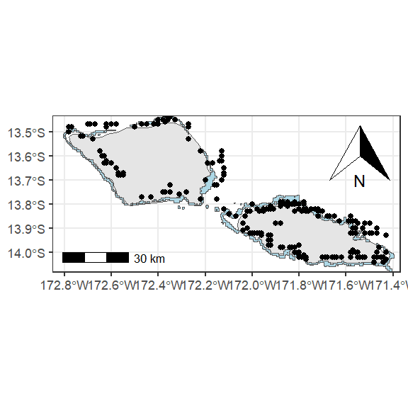

```r
cities<- maps::world.cities |>
  filter (country.etc == "Samoa") |>
  st_as_sf(coords = c("long", "lat"), crs = 4326)
Samoa<- rnaturalearth::ne_countries(scale = 10, country = "Samoa", returnclass = "sf")
#Samoa
bbox<- Samoa |> st_bbox()
ggplot()+
  geom_sf(data=Samoa)+
  geom_sf(data=reefs, fill = "lightblue") +
  geom_sf(data = cities) +
  #geom_point(data=cities, aes(y= lat, x=long))+
  #geom_text(data = cities, aes(y = lat,x = long-0.05,label = name), hjust=1)+
  ggspatial::annotation_north_arrow(location= "tr")+
  ggspatial::annotation_scale()+
  coord_sf(xlim=bbox[c("xmin", "xmax")],ylim = bbox[c("ymin", "ymax")])+
  theme_bw()+
  theme(axis.title = element_blank())
```

## 3.1 Exploratory data analysis

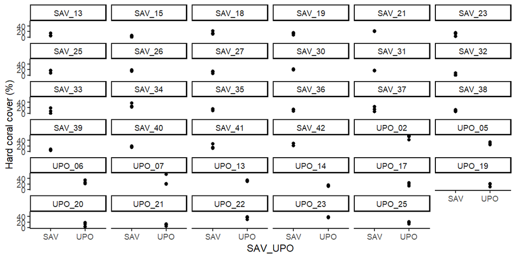

```r
dat |>
  filter(type == "point_machine_classification", GROUP == "HC") |>
  ggplot(aes(y =  100*COUNT/TOTAL, x = SAV_UPO)) +
  geom_point() +
  #geom_line(aes(group = transect_id)) +
  scale_y_continuous("Hard coral cover (%)") +
  #scale_colour_discrete("Survey depth (m)") +
  #scale_x_datetime("Year", date_breaks = "1 years", date_labels = "%Y") +
  facet_wrap(~site_name) +
  theme_classic()
```

```r
dat_hc <- dat |>
  filter(GROUP == "HC") |>
  droplevels()
```

**Boxplots**

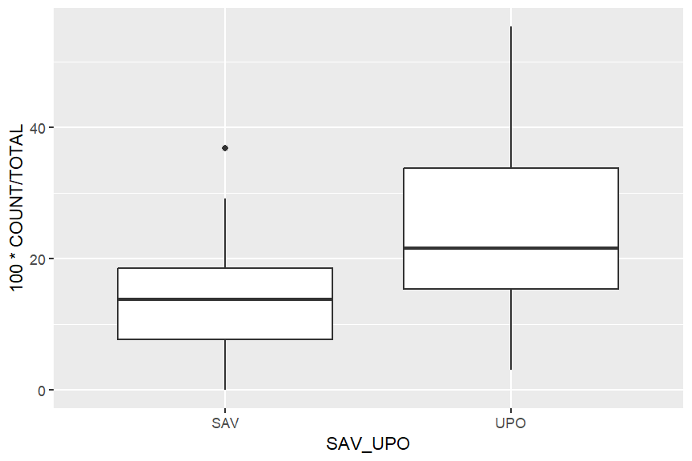

```r
dat |>
  filter(type == "point_machine_classification", GROUP == "HC") |>
  ggplot(aes(y =  100*COUNT/TOTAL, x = SAV_UPO)) +
  geom_boxplot()
```

**Conclusions -** variances are clearly not equal between the groups

Benthic monitoring programs typically adopt a hierarchical sampling design in which (usually) fixed sampling units (such as quadrats or transects) are nested within in Sites which are in turn nested within progressively larger spatial units (e.g. Reefs within Regions). In such designs, monitors collect data from those same units over multiple years. That is, the units are repeatedly measured.

Such a design is an attempt to control some of the numerous sources of uncertainty that would otherwise make it very difficult to draw out a signal (temporal pattern) amongst the noise. If instead, researchers sampled different locations each year, it is much harder to uncouple how much of any changes are due to genuine temporal shifts and how much is due to just a shift in location.

Whist this design does provide substantial statistical power advantages, it does introduce additional complexities to do with the independence of observations. Repeated observations from the same sampling units (transects etc) are not independent. Similarly, observations of sampling units that are close in space (or time) are likely to be highly correlated. This violates a important assumption that underlies most statistical analyses.

Complex hierarchical statistical designs exist to accommodate these dependency issues. Although such analyses are very powerful, they are not a good starting point when learning how to fit models. This series of workshops is intended to progressively increase the complexity of the statistical designs and analyses.

The current dataset represents only a tiny fraction of a much larger dataset that includes multiple sites, reefs and years. As such, it has been prepared to fill in for a very simple design/analyses.

**Important**

I fully acknowledge this issue and therefore acknowledge that the analysis I will present is completely invalid.

```r
dat_hc <- dat |>
  filter(GROUP == "HC") |>
  droplevels()
```

# 4 Fit models

**Binomial model**

**Define priors**

```r
priors <- prior(normal(0,1), class = "Intercept")+
  prior(normal(0,3), class = "b")+ #fixed prior
  prior(student_t(3, 0, 1), class = "sd") #random prior

form <- bf(COUNT | trials(TOTAL)~ SAV_UPO + (1|site_name)+ (1|transect_id),
           family = binomial(link = "logit"))
```

**Fit prior only model**

```r
model1<- brm(form,
             data = dat_hc,
             prior = priors,
             sample_prior = "only",
             iter = 5000,
             warmup = 1000,
             chains = 3,
             cores = 3,
             thin = 5,
             refresh = 1000,
             control = list(adapt_delta = 0.99, max_treedepth = 20),
             backend = "rstan")
```

```
Setting all 'trials' variables to 1 by default if not specified otherwise.
```

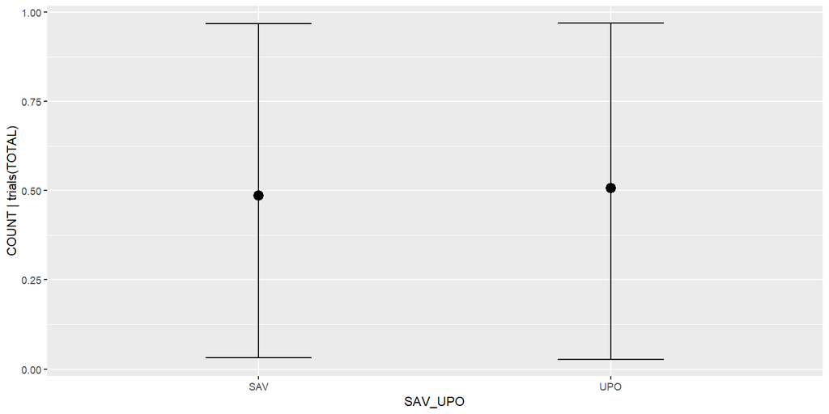

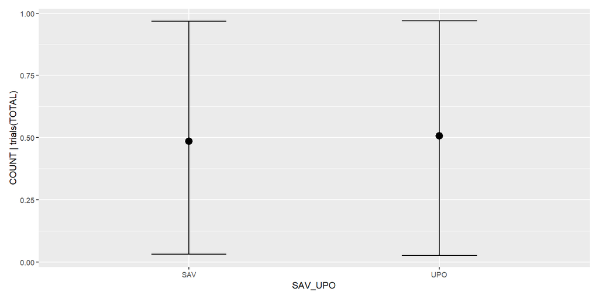

```r
model1 |>
  conditional_effects() |>
  plot( ask = FALSE) |>
  wrap_plots()
```

**Fit full model**

```r
model1 <- update(model1, sample_prior = "yes")
```

```
The desired updates require recompiling the model
```

**MCMC sampling diagnostics**

**Posterior probability checks**

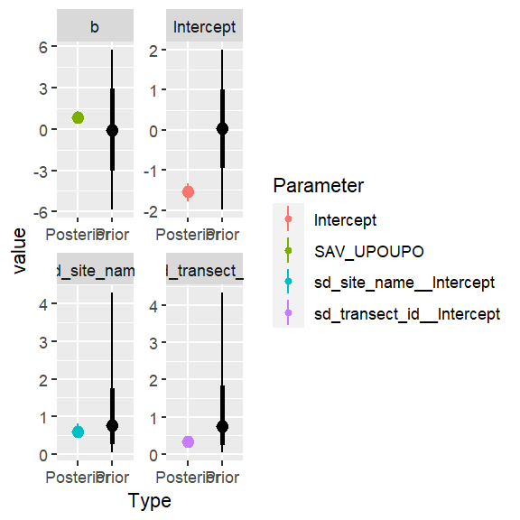

```r
model1 |>  SUYR_prior_and_posterior()
```

```
'pars' not specified. Showing first 10 parameters by default.
```

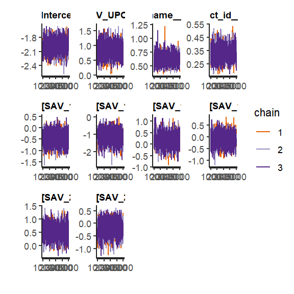

```r
model1$fit |> stan_trace()
```

```
'pars' not specified. Showing first 10 parameters by default.
```

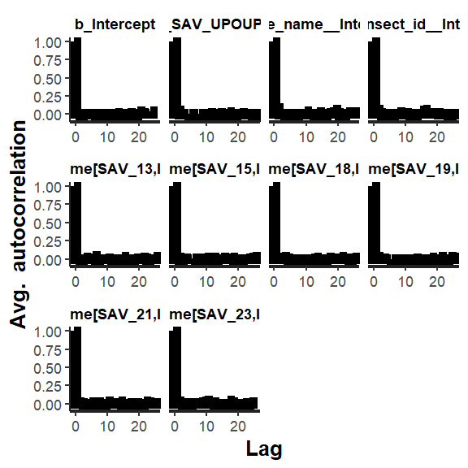

```r
model1$fit |> stan_ac()
```

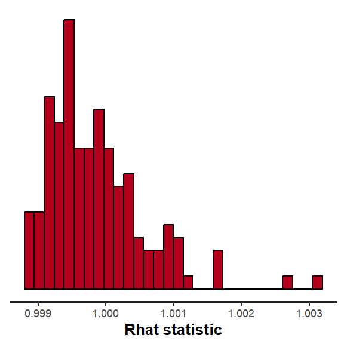

```r
model1$fit |> stan_rhat()
```

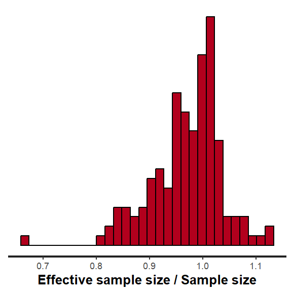

```r
model1$fit |> stan_ess()
```

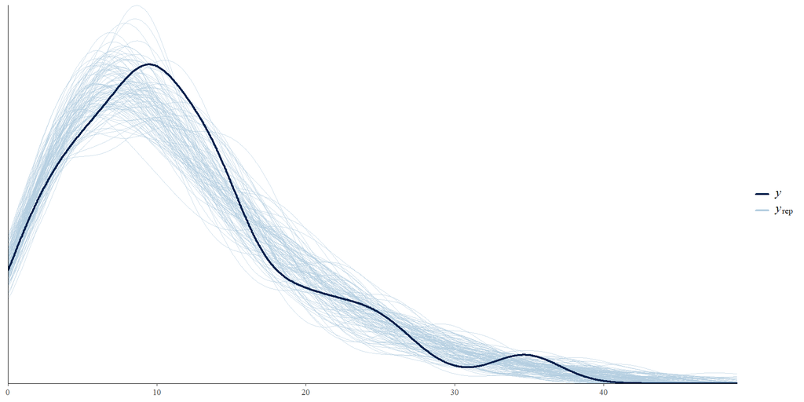

```r
model1 |> pp_check(type = "dens_overlay", ndraws = 100)
```

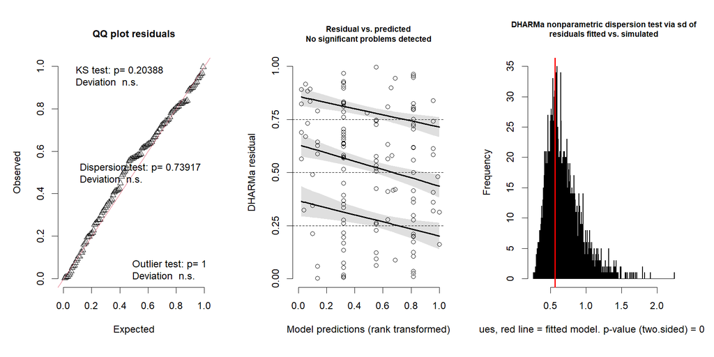

```r
resids <- model1 |> make_brms_dharma_res(integerResponse = FALSE)
wrap_elements(~testUniformity(resids))+
  wrap_elements(~plotResiduals(resids))+
  #wrap_elements(~plotResiduals(resids))+
  wrap_elements(~testDispersion(resids))
```

**Model validation**

# 5 Model posterior summaries

```r
model1 |> as_draws_df() |>
  summarise_draws(median, HDInterval::hdi,rhat,length,ess_bulk, ess_tail) |>
  knitr::kable() |>
  head()
```

```
[1] "|variable                        |       median|        lower|        upper|      rhat| length| ess_bulk| ess_tail|"
[2] "|:-------------------------------|------------:|------------:|------------:|---------:|------:|--------:|--------:|"
[3] "|b_Intercept                     |   -1.9716680|   -2.2677421|   -1.7068346| 1.0014422|   2400| 2402.533| 2127.484|"
[4] "|b_SAV_UPOUPO                    |    0.8596396|    0.4224503|    1.3524106| 0.9999661|   2400| 2169.064| 2218.490|"
[5] "|sd_site_name__Intercept         |    0.5952069|    0.4240500|    0.7844295| 1.0018410|   2400| 2062.760| 2154.366|"
[6] "|sd_transect_id__Intercept       |    0.3259145|    0.2225859|    0.4343799| 1.0011186|   2400| 2137.088| 2128.966|"
```

```r
plogis(-1.64)
```

```
[1] 0.1624651
```

# 6 Further explorations

## 6.1 Pairwise constrasts

```r
model1 |>
emmeans(~ SAV_UPO) |>
  regrid() |>
  pairs() |>
  gather_emmeans_draws() |>
  summarise(median_hdci(.value),
            Pl = mean(.value < 0),
            Pg = mean(.value > 0)) |>
 knitr::kable()
```

| contrast | y | ymin | ymax | .width | .point | .interval | Pl | Pg |
| --- | --- | --- | --- | --- | --- | --- | --- | --- |
| SAV - UPO | -0.1252541 | -0.1967116 | -0.0480425 | 0.95 | median | hdci | 1 | 0 |

```r
model1 |>
emmeans(~ SAV_UPO) |>
  regrid() |>
  regrid(trans = "log") |>
  pairs() |>
  gather_emmeans_draws() |>
  mutate(.value = exp(.value)) |>
  summarise(median_hdci(.value),
            Pl = mean(.value < 1),
            Pg = mean(.value > 1)) |>
 knitr::kable()
```

| contrast | y | ymin | ymax | .width | .point | .interval | Pl | Pg |
| --- | --- | --- | --- | --- | --- | --- | --- | --- |
| SAV - UPO | 0.494012 | 0.3278358 | 0.6951976 | 0.95 | median | hdci | 1 | 0 |

## 6.2 R2

```r
model1 |> bayes_R2(summary = FALSE, re_form = NA) |># ~(1|Reef_id) + (1| site_name)+ (1|transect_id)) |>
  median_hdci()|>
 knitr::kable()
```

| y | ymin | ymax | .width | .point | .interval |
| --- | --- | --- | --- | --- | --- |
| 0.3283899 | 0.1729199 | 0.4859164 | 0.95 | median | hdci |

```r
model1 |> bayes_R2(summary = FALSE, re_form = ~(1|site_name) + (1| transect_id)) |>
 median_hdci() |>
 knitr::kable()
```

| y | ymin | ymax | .width | .point | .interval |
| --- | --- | --- | --- | --- | --- |
| 0.8819083 | 0.850103 | 0.9127625 | 0.95 | median | hdci |

```r
model1 |> bayes_R2(summary = FALSE, re_form = ~ (1|transect_id)) |>
  median_hdci()|>
 knitr::kable()
```

| y | ymin | ymax | .width | .point | .interval |
| --- | --- | --- | --- | --- | --- |
| 0.4796958 | 0.314046 | 0.6117805 | 0.95 | median | hdci |

# 7 Summary figures

```
Setting all 'trials' variables to 1 by default if not specified otherwise.
```

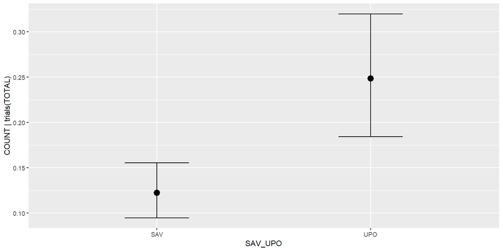

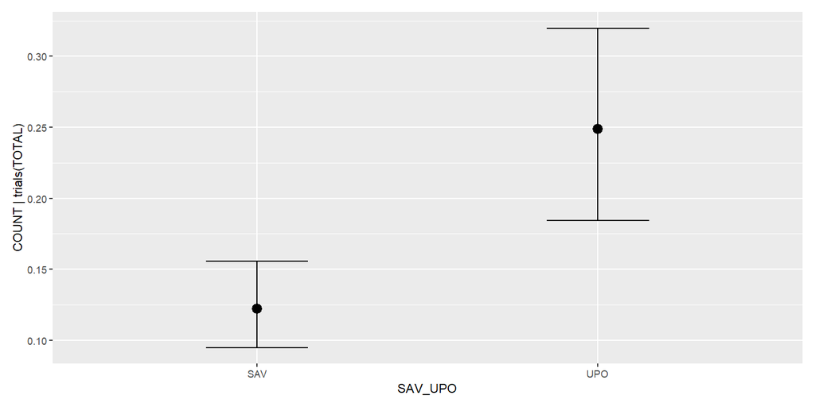

```r
model1 |>
  conditional_effects() |>
  plot( ask = FALSE) |>
  wrap_plots()
```

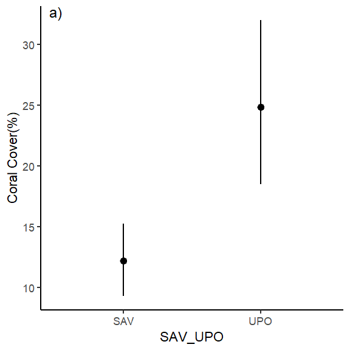

```r
g1<-
  model1 |>
  emmeans(~SAV_UPO, type = "response") |>
  as.data.frame() |>
  #gather_emmeans_draws() |>
  #mutate(fit = plogis(.value)) |>
  #summarise(median_hdci(fit)) |>
  ggplot(aes(y = prob, x = SAV_UPO))+
  geom_pointrange(aes(ymin = lower.HPD, ymax = upper.HPD))+
  scale_y_continuous("Coral Cover(%)", labels = scales::label_number(scale = 100))+
  #scale_x_discrete("COTs Outbreak", breaks = c(0,1), labels = c("No COTs", "COTS"))+
  theme_classic()
#| fig.width: 8
#| fig.height: 4
(g1 +annotate_npc("  a)", x = 0, y = 1, hjust = 0, vjust = 1))
```

```r
g2<-
   model1|>
  emmeans(~SAV_UPO,type = "response") |>
  regrid () |>
  pairs() |> #percentage changes to produce the plot
  gather_emmeans_draws() |> #give me all 2400 of the values
  mutate(contrast = str_replace_all(contrast, "SAV_UPO", "")) |> #replace fYear with nothing
  ggplot(aes(x = .value, y = contrast))+ #the column .value on x axis
  stat_halfeye(aes(fill = after_stat(level)), .width = c(0.66, 0.95,1))+ #produce density plots and fill it according to different proportion of the data
 # scale_fill_viridis_c() +
  scale_fill_brewer(palette = "Blues")+ #overwritten to have a different color pallet, color brewer is used for mapping you can change it to any color
  geom_vline(xintercept = 0, linetype = "dashed")+ #dashed line
  scale_x_continuous("Effect size")+ #providing nicer labels
  scale_y_discrete("") +
  theme_classic()
```

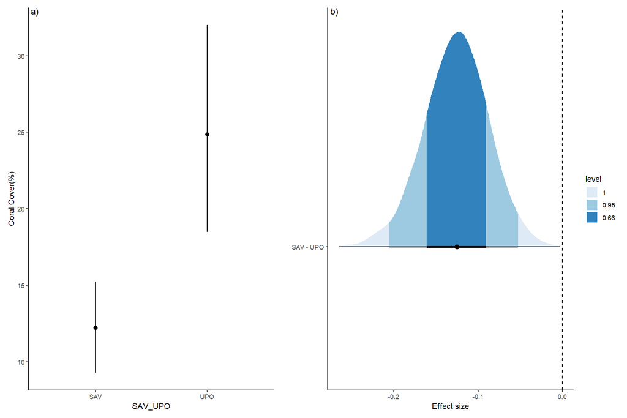

```r
(g1 +annotate_npc(" a)", x = 0, y = 1, hjust = 0, vjust = 1))+
(g2 + annotate_npc(" b)", x = 0, y = 1, hjust = 0, vjust = 1))
```